# Proyecto 1 - Relación Minutos Ingreso

## Integrantes del Grupo :

Juan Felipe Ramírez Botero

## Explicación Breve del Problema:

### ¿Existe relación alguna entre el total de minutos usados con la compañía y el ingreso total de los clientes?

La revisión del comportamiento de los clientes en cualquier empresa es de vital importancia para el desarrollo de estrategias tanto de mejoramiento de productos como de publicidad y toma de decisiones. Evaluaremos la información del conjunto de registros Credito_dias.csv de una empresa de telecomunicaciones que cuenta las siguientes variables:

totrev: Ingresos del cliente.

totmou: Total de minutos usados por el cliente.

creditcd: Indicador de tarjeta de crédito.

eqpdays: Número de días (antigüedad) del equipo actual.

Es importante mencionar que la empresa contiene una gran cantidad de clientes y hacer el análisis uno a uno no es lo óptimo. Con ayuda de la programación y el análisis de datos, se logrará llegar a conclusiones rápidas y acertadas para encontrar relaciones que a simple vista no son tenidas en cuenta.

### ¿Qué se quiere identificar?

Teniendo en cuenta la información de la base de datos, se quiere identificar si hay una relación entre el total de minutos usados por el cliente con la compañía y el ingreso total de los clientes, es decir, ¿Será posible afirmar que cuando una persona tiene un mayor ingreso, entonces es mayor la utilización de minutos o todo lo contrario?

```python
# Importar librerías
import pandas as pd
import seaborn as sns
import matplotlib.pyplot as plt
# Cargar datos
data = pd.read_csv("https://raw.githubusercontent.com/Izainea/seminario-de-programacion/master/Cuadernos/Clase%202/Bases/Credito_dias.csv")
```

```python
display(data.shape)
data.head()
```

```
(10000, 5)
```

|  | totmou | totrev | creditcd | eqpdays | Customer_ID |
| --- | --- | --- | --- | --- | --- |
| 0 | 7269.0 | 906.58 | Y | 371 | 1082423 |
| 1 | 13552.0 | 1172.25 | N | 83 | 1069232 |
| 2 | 4152.0 | 577.39 | Y | 675 | 1031705 |
| 3 | 1863.0 | 294.26 | Y | 218 | 1089806 |
| 4 | 4155.0 | 433.16 | N | 222 | 1076695 |

```python
# Revisión de valores nulos
data.isnull().sum()
```

```
totmou           0
totrev           0
creditcd       152
eqpdays          0
Customer_ID      0
dtype: int64
```

```python
# Eliminar valores nulos
data = data.dropna()

# Revisión de valores nulos
data.isnull().sum()
```

```
totmou         0
totrev         0
creditcd       0
eqpdays        0
Customer_ID    0
dtype: int64
```

```python
# convertir la variable de customer_id a indice
data = data.set_index("Customer_ID")
data.head()
```

| Customer_ID | totmou | totrev | creditcd | eqpdays |
| --- | --- | --- | --- | --- |
| 1082423 | 7269.0 | 906.58 | Y | 371 |
| 1069232 | 13552.0 | 1172.25 | N | 83 |
| 1031705 | 4152.0 | 577.39 | Y | 675 |
| 1089806 | 1863.0 | 294.26 | Y | 218 |
| 1076695 | 4155.0 | 433.16 | N | 222 |

## Análisis Exploratorio de Cada Variable

```python
#Convertir variable creditcd a tipo categorico
data["creditcd"] = data["creditcd"].astype("category")
display(data.creditcd.value_counts())
# Descripción de cada variable numérica
data.describe()
```

```
creditcd
Y    6796
N    3052
Name: count, dtype: int64
```

|  | totmou | totrev | eqpdays |
| --- | --- | --- | --- |
| count | 9848.000000 | 9848.000000 | 9848.000000 |
| mean | 7697.900458 | 1042.302115 | 386.982433 |
| std | 8662.012934 | 857.945971 | 252.473800 |
| min | 0.000000 | 11.100000 | -5.000000 |
| 25% | 2575.000000 | 526.627500 | 210.000000 |
| 50% | 5261.500000 | 820.955000 | 338.000000 |
| 75% | 9842.000000 | 1272.975000 | 523.000000 |
| max | 163264.176700 | 13426.600000 | 1823.000000 |

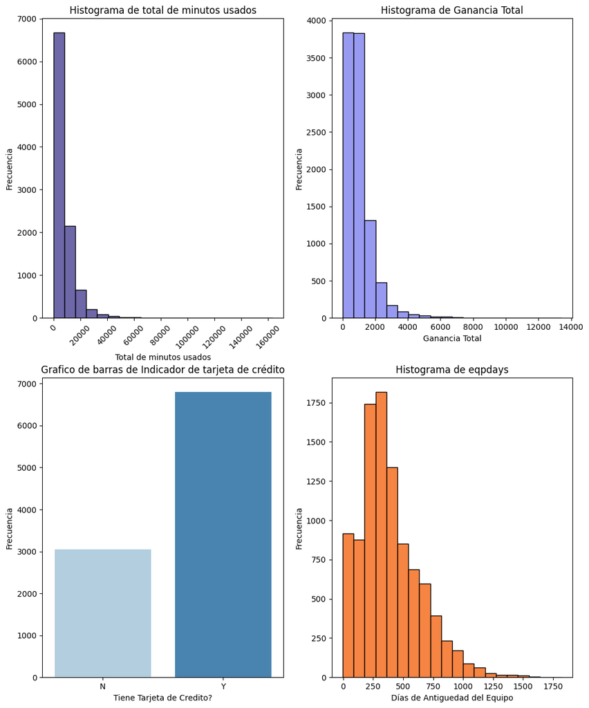

```python
#Histogramas para variables numéricas y gráfico de barras para variables categoricas

fig, axs = plt.subplots(2, 2, figsize=(12, 15))

# Histograma de totmou
sns.histplot(data["totmou"], color="#3D348B", bins=20, ax=axs[0, 0])
axs[0, 0].set_title("Histograma de total de minutos usados")
axs[0, 0].set_xlabel("Total de minutos usados")
axs[0, 0].set_ylabel("Frecuencia")
axs[0, 0].set_xticklabels(axs[0, 0].get_xticklabels(), rotation=45)

# Histograma de totrev
sns.histplot(data["totrev"], color="#7678ED", bins=20, ax=axs[0, 1])
axs[0, 1].set_title("Histograma de Ganancia Total")
axs[0, 1].set_xlabel("Ganancia Total")
axs[0, 1].set_ylabel("Frecuencia")

# Grafico de barras de creditcd
sns.countplot(x="creditcd", hue="creditcd", data=data, palette="Blues", ax=axs[1, 0])
axs[1, 0].set_title("Grafico de barras de Indicador de tarjeta de crédito")
axs[1, 0].set_xlabel("Tiene Tarjeta de Credito?")
axs[1, 0].set_ylabel("Frecuencia")

# Histograma de eqpdays
sns.histplot(data["eqpdays"], color="#F35B04", bins=20, ax=axs[1, 1])
axs[1, 1].set_title("Histograma de eqpdays")
axs[1, 1].set_xlabel("Días de Antiguedad del Equipo")
axs[1, 1].set_ylabel("Frecuencia")

plt.show()
```

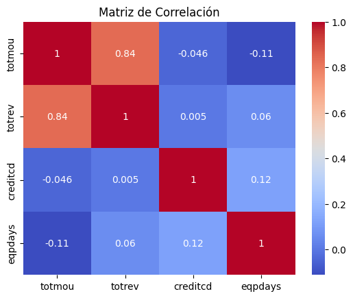

```python
#Codificar la variable creditcd para poder hacer posteriormente una matriz de correlaciones
data1 = data.copy()

data1["creditcd"] = data["creditcd"].cat.codes

#Mapa de calor con la matriz de correlaciones

matriz = data1.corr()

sns.heatmap(matriz, annot=True, cmap='coolwarm')
plt.title('Matriz de Correlación')
plt.show()
```

## Diagrama de dispersión entre las variables totrev y totmou

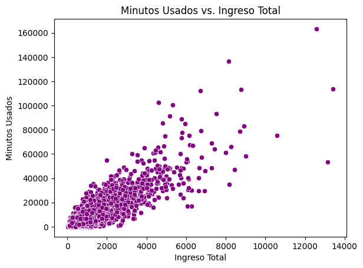

```python
# Diagrama de dispersión entre las variables totrev y totmou
sns.scatterplot(x="totrev", y="totmou", data=data, color= "purple")
plt.title("Minutos Usados vs. Ingreso Total")
plt.xlabel("Ingreso Total")
plt.ylabel("Minutos Usados")
plt.show()
```

### Conclusión 1

Tanto la matriz de correlación como el gráfico de dispersión muestran una fuerte relación lineal y directamente proporcional entre el ingreso total y el total de minutos usados por los clientes. Esto indica que un mayor ingreso se corresponde con un mayor uso de minutos.

## ¿Existe relación alguna entre el total de minutos usados con la compañía y el ingreso total de los clientes?

```python
#Correlación entre total de minutos y total de ingresos
round(data["totrev"].corr(data["totmou"]), 3)
```

```
0.835
```

Dado que la correlación entre el total de minutos y el total de ingresos es de 0.835, se puede afirmar que existe una fuerte correlación positiva entre las dos variables, reafirmando lo ilustrado por el gráfico de dispersión del apartado anterior. Nuevamente se indica que los clientes de mayor ingreso utilizan más minutos.

## ¿El hecho de tener crédito afecta alguna de estas dos variables(minutos usados|ingreso total)?

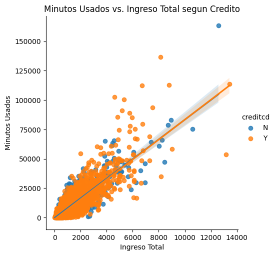

```python
#diagrama de dispersión superpuesto con leyenda que indique si tiene crédito o no
sns.lmplot(x="totrev", y="totmou", data=data, hue="creditcd", legend=True )
plt.title("Minutos Usados vs. Ingreso Total segun Credito")
plt.xlabel("Ingreso Total")
plt.ylabel("Minutos Usados")
plt.show()
```

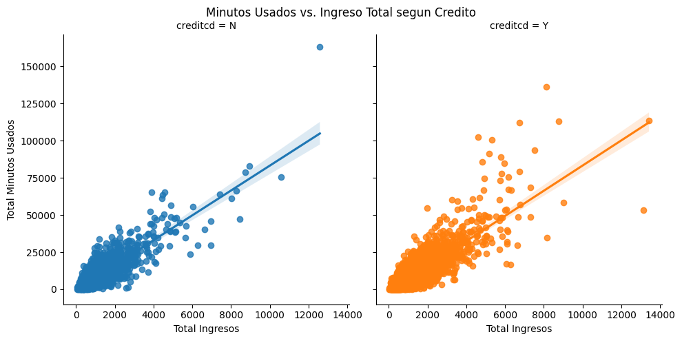

```python
# Crear el diagrama de dispersión lado a lado con lmplot
g = sns.lmplot(x="totrev", y="totmou", data=data, hue="creditcd", col="creditcd", legend=True)

# Añadir títulos a los gráficos
g.fig.suptitle("Minutos Usados vs. Ingreso Total segun Credito")

# Etiquetas de ejes
g.set_axis_labels("Total Ingresos", "Total Minutos Usados")

plt.subplots_adjust(top=0.9)
plt.show()
```

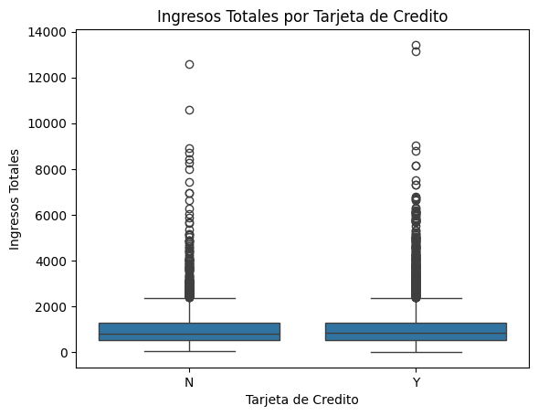

```python
#gráfico de caja de ingreso total según tarjeta

sns.boxplot(x="creditcd", y="totrev", data=data)
plt.title("Ingresos Totales por Tarjeta de Credito")
plt.xlabel("Tarjeta de Credito")
plt.ylabel("Ingresos Totales")
plt.show()
```

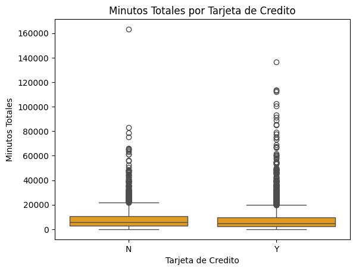

```python
# Gráfico de caja de minutos usados por tarjeta

sns.boxplot(x="creditcd", y="totmou", data=data, color="orange")
plt.title("Minutos Totales por Tarjeta de Credito")
plt.xlabel("Tarjeta de Credito")
plt.ylabel("Minutos Totales")
plt.show()
```

## Conclusión 2

Luego de realizar visualizaciones tanto de la diferencia de distribuciones de ambas variables respecto de si el cliente tiene o no tarjeta de crédito con los gráficos de caja, además de visualizar su relación con los gráficos de dispersión con línea de tendencia, no hay ninguna diferencia aparente entre el total de minutos usados ni en el total de ingresos del cliente si utiliza o no una tarjeta de crédito.

[figure not shown]

Created in Deepnote